# Prediction Assignment Writeup

Gonzalo Canto

February 7th 2019

# Overview

### The goal of this project is to predict the manner in which they did the exercise. This is the “classe” variable in the training set. I may use any of the other variables to predict with. I should create a report describing how I built my model,how I used cross validation, what I think the expected out of sample error is,and why I made the choices I did. I will also use my prediction model to predict 20 different test cases.

# Download and clean the dataset

### Firstly I loaded the packages that I will need for the project

```r
library(ggplot2)
library(caret)
library(randomForest)
```

### Then I download the data files from the URL provided with the na.strings argument and then I check the dimension of both Traning and Testing set

```r
Training <- read.csv("https://d396qusza40orc.cloudfront.net/predmachlearn/pml-training.csv",na.strings=c("NA","#DIV/0!",""))
Testing <- read.csv("https://d396qusza40orc.cloudfront.net/predmachlearn/pml-testing.csv",na.strings=c("NA","#DIV/0!",""))
dim(Training)
```

```
## [1] 19622   160
```

```r
dim(Testing)
```

```
## [1]  20 160
```

# Clean Data

```r
Training2 <-Training[,colSums(is.na(Training)) == 0]
Testing2 <-Testing[,colSums(is.na(Testing)) == 0]
Training3 <-Training2[,c(8:60)]
Testing3 <-Testing2[,c(8:60)]
```

# Partition Training Set

### In this section I split our dataset, I am going to build a training set and a test set, 70% for train data, 30% for test data this will be used for cross validation

```r
set.seed(1050)
inTrain <- createDataPartition(Training3$classe, p=0.7, list=FALSE)
TrainingFinal <- Training3[inTrain, ]
TestingFinal <- Training3[-inTrain, ]
```

### I check the new dimensions for the final training and test set

```r
dim(TrainingFinal)
```

```
## [1] 13737    53
```

```r
dim(TestingFinal)
```

```
## [1] 5885   53
```

# Data Prediction and Modelling

### I fit my prediction model. I choose Random forest due to its accuracy rate. This way the error should be small estimated by using the 30% testing sample.

```r
modfit <- randomForest(classe ~., data=TrainingFinal, method="class")
```

### Plot to visualise the model that has been built.

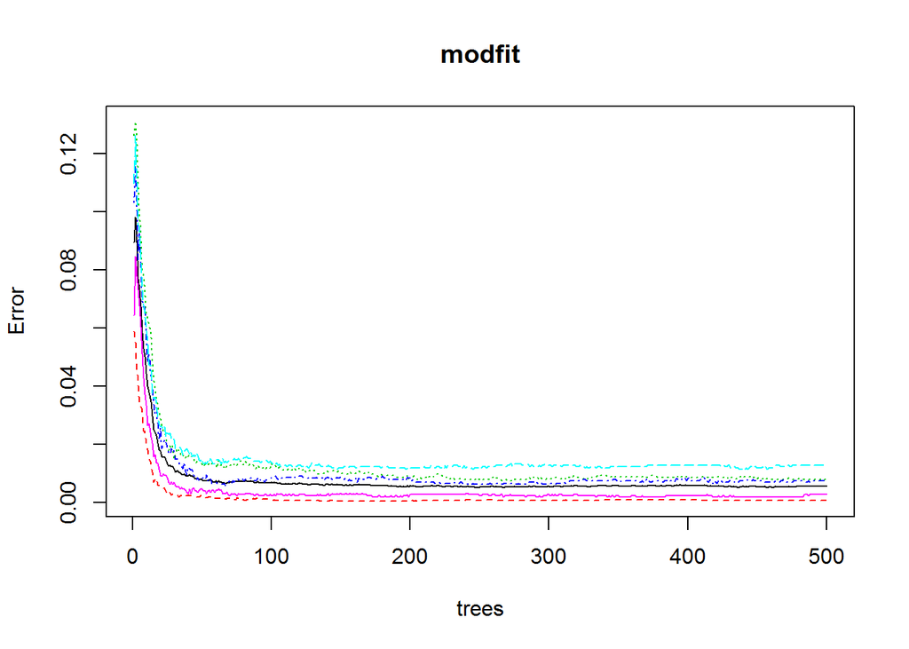

```r
plot(modfit)
```

### Now I use cross validation, to evaluate our predicted model.

```r
RandomFPrediction <- predict(modfit, TestingFinal, Type="class")
```

### The confusion matrix will evaluate the performance of the classification model.

```r
confusionMatrix(RandomFPrediction, TestingFinal$classe)
```

```
## Confusion Matrix and Statistics
##
##           Reference
## Prediction    A    B    C    D    E
##          A 1674    7    0    0    0
##          B    0 1130    7    0    0
##          C    0    2 1019    8    0
##          D    0    0    0  956    2
##          E    0    0    0    0 1080
##
## Overall Statistics
##
##                Accuracy : 0.9956
##                  95% CI : (0.9935, 0.9971)
##     No Information Rate : 0.2845
##     P-Value [Acc > NIR] : < 2.2e-16
##
##                   Kappa : 0.9944
##  Mcnemar's Test P-Value : NA
##
## Statistics by Class:
##
##                      Class: A Class: B Class: C Class: D Class: E
## Sensitivity            1.0000   0.9921   0.9932   0.9917   0.9982
## Specificity            0.9983   0.9985   0.9979   0.9996   1.0000
## Pos Pred Value         0.9958   0.9938   0.9903   0.9979   1.0000
## Neg Pred Value         1.0000   0.9981   0.9986   0.9984   0.9996
## Prevalence             0.2845   0.1935   0.1743   0.1638   0.1839
## Detection Rate         0.2845   0.1920   0.1732   0.1624   0.1835
## Detection Prevalence   0.2856   0.1932   0.1749   0.1628   0.1835
## Balanced Accuracy      0.9992   0.9953   0.9956   0.9956   0.9991
```

### The random forest model performed very well with 99.6% Accuracy.

### In order to see the model performace more clearly I get the accuracy and the estimated out-of-sample error.

```r
accuracy <- postResample(RandomFPrediction, TestingFinal$classe)
error<-1 - as.numeric(confusionMatrix(TestingFinal$classe, RandomFPrediction)$overall[1])
```

The accuracy of the model is 99.6% and the estimated out-of-sample error is 0.4%

# 20 different test cases

### I use the model with the test data provided in the beginning

```r
Prediction <- predict(modfit, Testing)
Prediction
```

```
##  1  2  3  4  5  6  7  8  9 10 11 12 13 14 15 16 17 18 19 20
##  B  A  B  A  A  E  D  B  A  A  B  C  B  A  E  E  A  B  B  B
## Levels: A B C D E
```